# Regularity Conditions for Consistency of Jeffreys Approximate Objective Bayes Factor in Seven or More Experiments

#### **R1**

We set the model parameters to $I=4$, $\mu=2$, $\alpha_1=\alpha_2=\alpha_3=\alpha_4=0$, $\sigma_s=3$, and $\sigma_\epsilon=1$, resulting in a correlation of $\rho=\sigma_s^2\ /\ (\sigma_s^2+\sigma_\epsilon^2)=.9$ between any two observation collected on the same subject.

$\mu_i=\mu+\alpha_i$ and $\mu_0=\frac{1}{I}\sum_{i=1}^I\mu_i$

$\mathcal{H}_0:\boldsymbol{\theta}=(\mu_1-\mu_0,\ \mu_2-\mu_0,\ \mu_3-\mu_0)^\top=\boldsymbol{0}$

```r
nSim <- 5000 # number of simulation runs for each setting
n <- c(10, 25, 50, 100, 250, 500) # numbers of subjects
```

```r
computeDist5 <- function(n, m1=2, m2=2, m3=2.25, m4=2.5, sigma_e=1, sigma_s=3) {
  #' Input -
  #' n:              number of subjects
  #' m1:             population mean for the first condition
  #' m2:             population mean for the second condition
  #' m3:             population mean for the third condition
  #' m4:             population mean for the fourth condition
  #' sigma_e:        true error standard deviation
  #' sigma_s:        standard deviation of the subject-specific random effects
  #'
  #' Output -
  #' a list of the p-value and $D_{N}=\sqrt{N}\cdot p\cdot(-\ln{p})$ in Eq. 7

  df <- data.frame("resp"=stats::rnorm(n*4, c(m1, m2, m3, m4), sigma_e) +
                          rep(stats::rnorm(n, 0, sigma_s), each=4),
                   "cond"=rep(paste0("cond", 1:4), n),
                   "ID"=rep(paste0("s", 1:n), each=4), stringsAsFactors=T)
  pVal <- summary(stats::aov(resp ~ cond + Error(ID/cond), df))[[2]][[1]]["cond", "Pr(>F)"]
  # pVal <- summary(stats::aov(resp ~ cond + ID, df))[[1]][1, "Pr(>F)"] # same results but significantly faster
  list("p"=pVal,
       "D"=sqrt(n*3) * pVal * -log(pVal) ) # use total number of independent observations
}

set.seed(277)
pMat5 <- sapply(n, function(x) replicate(nSim, computeDist5(x, m3=2, m4=2)$p)) # roughly 5.4 hours of run time
```

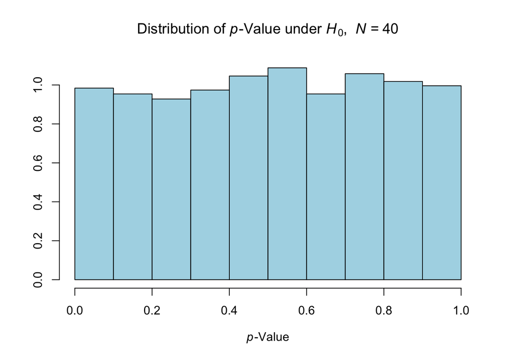

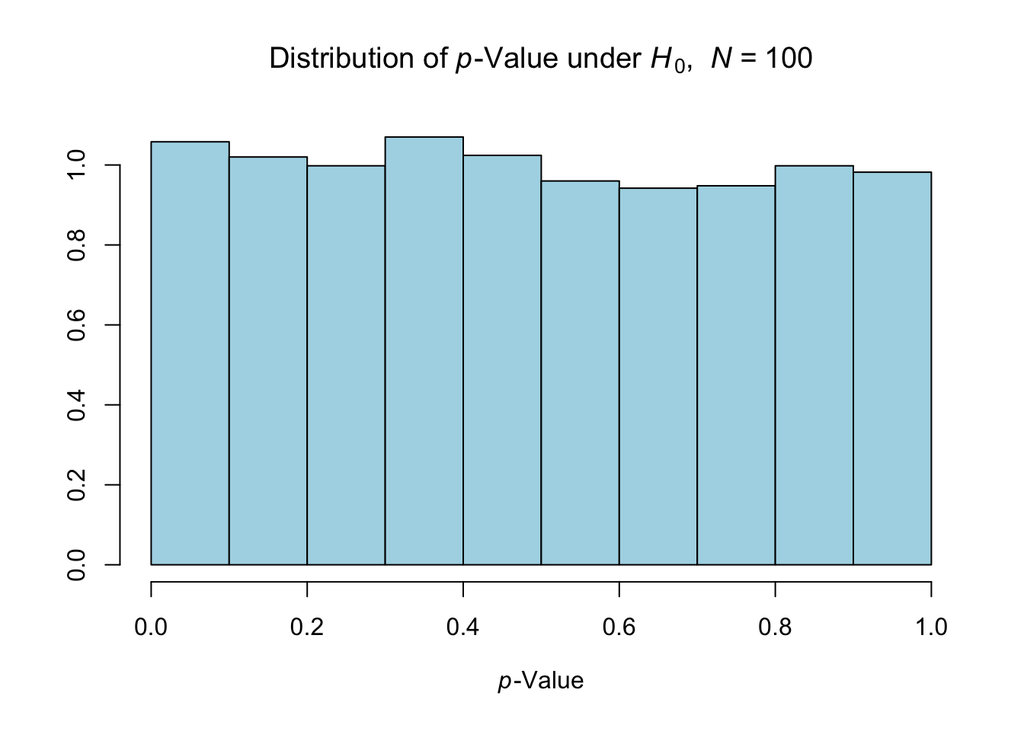

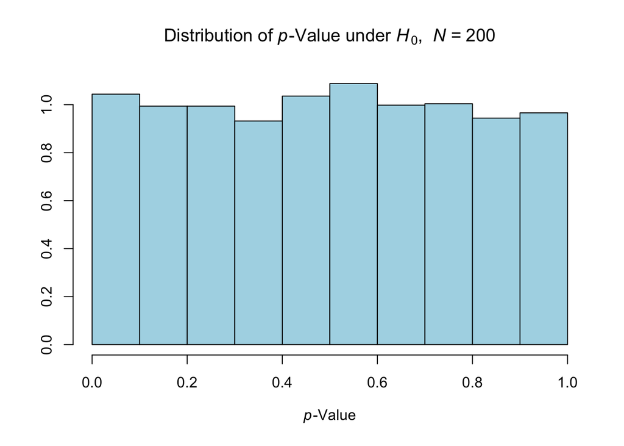

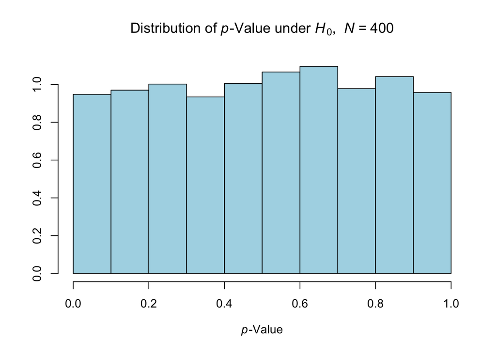

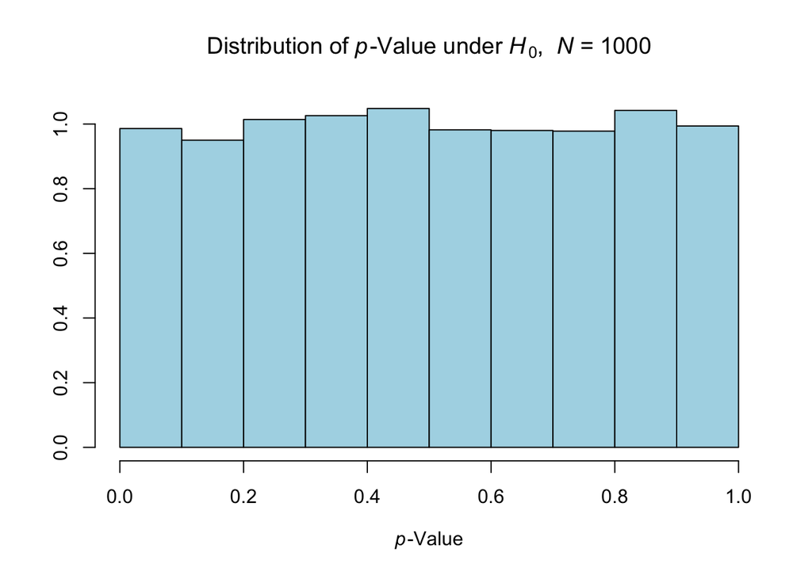

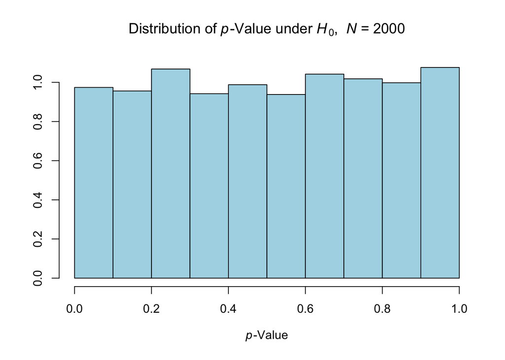

```r
for (i in 1:length(n)) {
  hist(pMat5[,i], prob=T, main=bquote("Distribution of " * italic("p") * "-Value under "
                                      * italic("H")[0] * ",  " * italic("N = ") * .(4*n[i])),
       xlab=expression(italic(p) * "-Value"), ylab="", col="lightblue")
  cat("<br><br>")
} # create the histograms
```

The regularity condition **R1** appears to hold for one-way repeated-measures ANOVA.

scroll to top

#### **R2**

We set the model parameters to $I=4$, $\mu=2$, $\alpha_1=0$, $\alpha_2=0$, $\alpha_3=0.25$, $\alpha_4=0.5$, $\sigma_s=3$, and $\sigma_\epsilon=1$, resulting in a correlation of $\rho=\sigma_s^2\ /\ (\sigma_s^2+\sigma_\epsilon^2)=.9$ between any two observation collected on the same subject.

$\mu_i=\mu+\alpha_i$ and $\mu_0=\frac{1}{I}\sum_{i=1}^I\mu_i$

$\mathcal{H}_1:\boldsymbol{\theta}=(\mu_1-\mu_0,\ \mu_2-\mu_0,\ \mu_3-\mu_0)^\top\neq\boldsymbol{0}$

For examining the regularity conditions, the sample size in $D_N$ is taken to be $n(I-1)$ to account for repeated-measures correlation. This simple choice is made primarily for convenience and should not effect the results as they pertain to behavior of $D_N$ since it is the number of subjects tending to infinity while the number of conditions is fixed to $I=4$.

```r
set.seed(277)
distMat5 <- sapply(n, function(x) replicate(nSim, computeDist5(x)$D)) # roughly 5.5 hours of run time
```

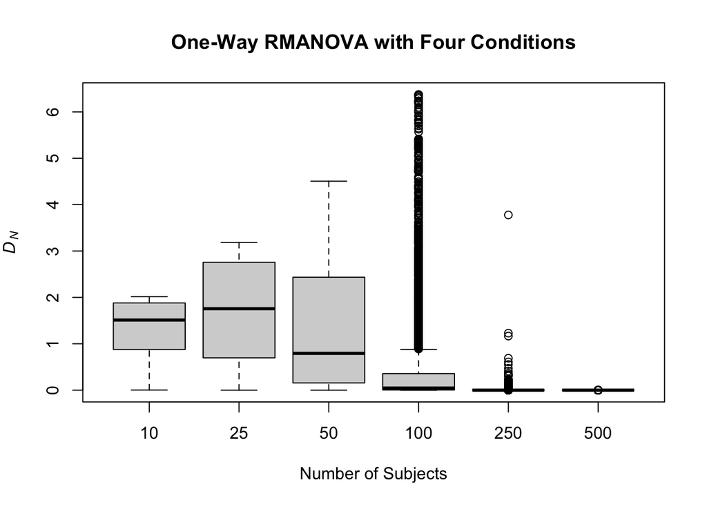

```r
boxplot(distMat5, names=n, ylab=expression(italic(D)[italic(N)]), xlab="Number of Subjects",
        main="One-Way RMANOVA with Four Conditions") # create the boxplot
```

The regularity condition **R2** appears to hold for one-way repeated-measures ANOVA.

scroll to top

### $\chi^{2}$-Test

Design (Note that each row may not have been normalized.)

| $\mathcal{H}_1$ | $\pi_1$ | $\pi_2$ | $1-\pi_1-\pi_2$ | 1 | $\mathcal{H}_0$ | $\pi_1$ | $\pi_2$ | $1-\pi_1-\pi_2$ | 1 |
| --- | --- | --- | --- | --- | --- | --- | --- | --- | --- |
|  | $\pi_1-\delta$ | $\pi_2+\delta$ | $1-\pi_1-\pi_2$ | 1 |  | $\pi_1$ | $\pi_2$ | $1-\pi_1-\pi_2$ | 1 |
|  | $\pi_1+\delta$ | $\pi_2-\delta$ | $1-\pi_1-\pi_2$ | 1 |  | $\pi_1$ | $\pi_2$ | $1-\pi_1-\pi_2$ | 1 |
|  | $3\pi_1$ | $3\pi_2$ | $3-3\pi_1-3\pi_2$ | 3 |  | $3\pi_1$ | $3\pi_2$ | $3-3\pi_1-3\pi_2$ | 3 |

The sample size $N$ is the total number of observations. The degrees of freedom are $q=(R-1)(C-1)$.

#### **R1**

Let $\pi_1=\pi_2=.25$ and $\delta=0$. Assume that the total number is fixed (`jointMulti`).

```r
nSim <- 5000 # number of simulation runs for each setting
size <- c(100, 250, 500, 1000, 2000, 3000) # average numbers of objects per row
```

```r
computeDist6 <- function(size, p1=.25, p2=.25, delta=0.075) {
  #' Input -
  #' size:            average number of objects per row
  #' p1:              proportion in the first row and first column of a 3×3 contingency table
  #' p2:              proportion in the first row and second column of a 3×3 contingency table
  #' delta:           designated proportion difference
  #'
  #' Output -
  #' a list of the p-value and $D_{N}=\sqrt{N}\cdot p\cdot(-\ln{p})$ in Eq. 7

  prob_H0 <- c(p1, p2, 1-p1-p2) # probabilities for the three column classes under the null
  prob_delta <- c(-delta, delta, 0) # effect sizes
  mat <- matrix(stats::rmultinom(1, size * 3, c(prob_H0,
                                                prob_H0 + prob_delta,
                                                prob_H0 - prob_delta)), ncol=3, byrow=T) # `jointMulti`
  pVal <- stats::chisq.test(mat)$p.value # p-value of the chi-squared test
  list("p"=pVal,
       "D"=sqrt(size * 3) * pVal * -log(pVal) ) # use total number of objects
}

set.seed(277)
pMat6 <- sapply(size, function(x) replicate(nSim, computeDist6(x, delta=0)$p)) # roughly 0.8 seconds of run time
```

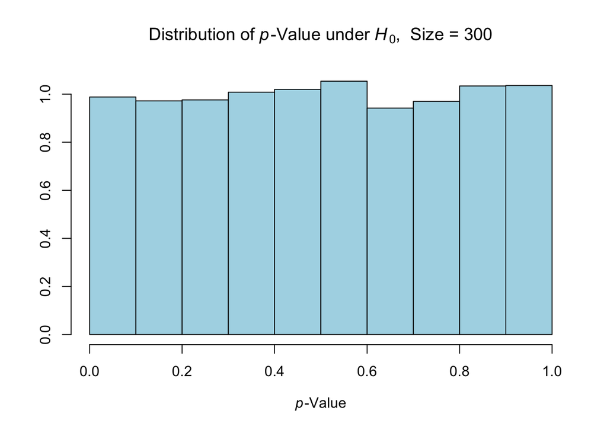

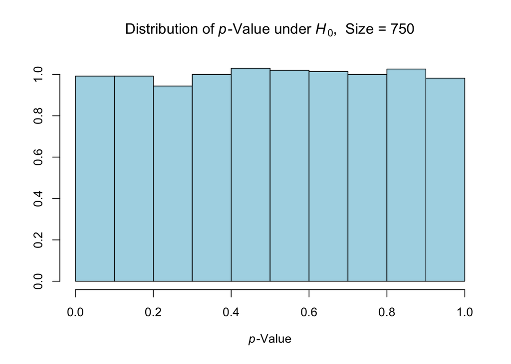

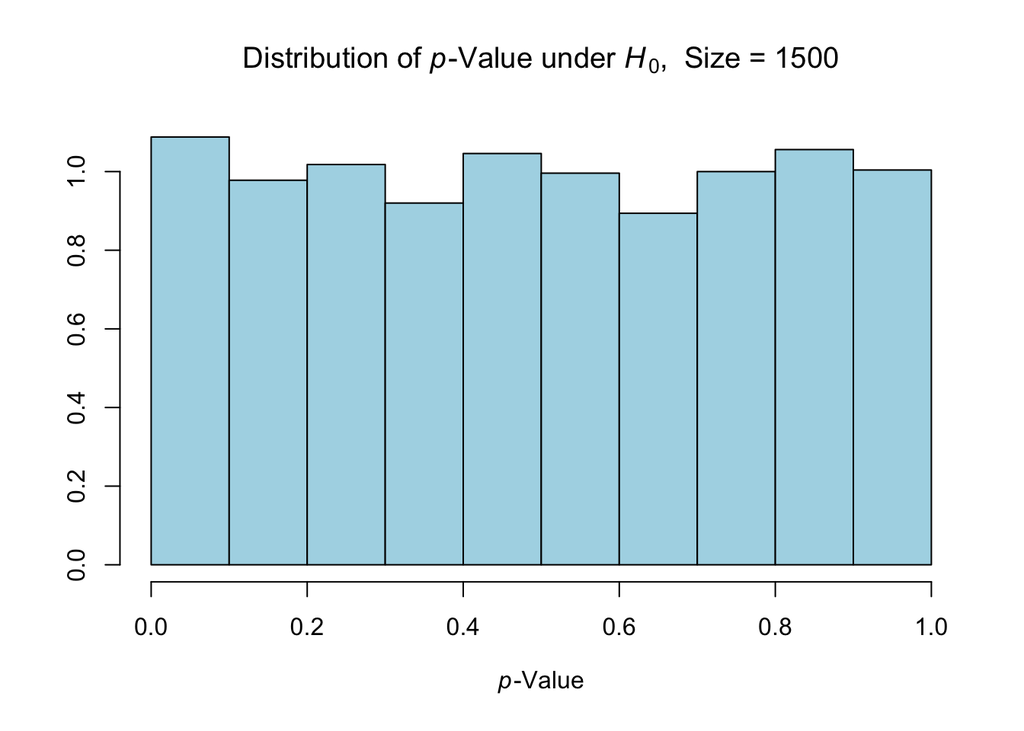

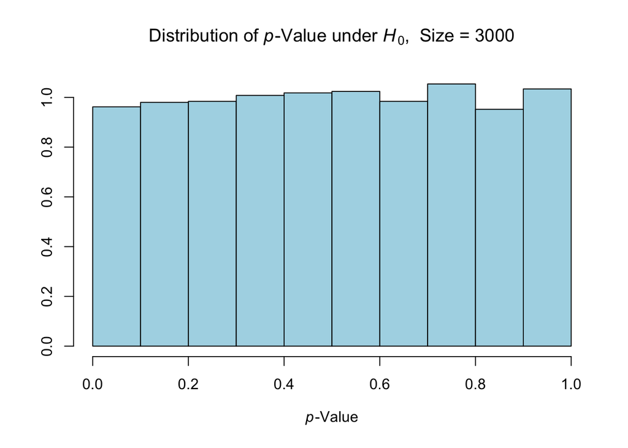

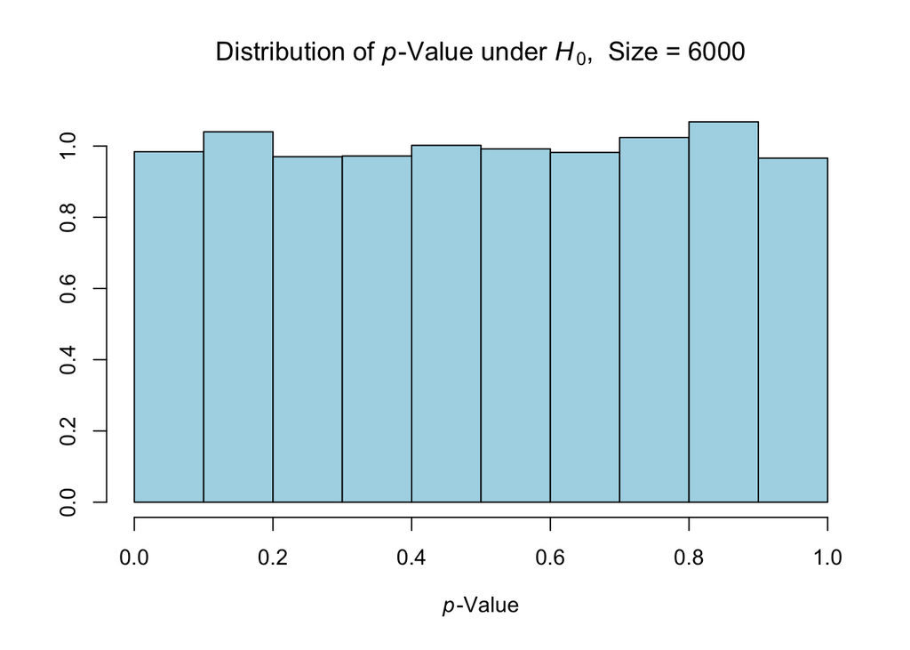

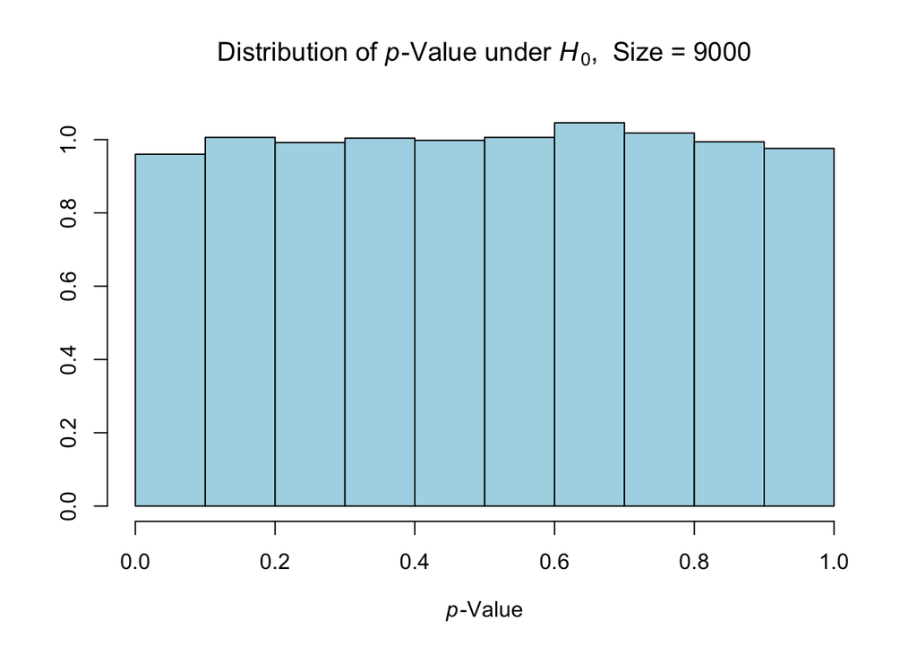

```r
for (i in 1:length(size)) {
  hist(pMat6[,i], prob=T, main=bquote("Distribution of " * italic("p") * "-Value under "
                                      * italic("H")[0] * ",  Size = " * .(3*size[i])),
       xlab=expression(italic(p) * "-Value"), ylab="", col="lightblue")
  cat("<br><br>")
} # create the histograms
```

The regularity condition **R1** holds for the $\chi^2$-test.

The smallest sample size is $3\times100$ to ensure accuracy of the $\chi^{2}$ test with no cells having an expected count lower than 5.

scroll to top

#### **R2**

Let $\pi_1=\pi_2=.25$ and $\delta=0.075$. Assume that the total number is fixed (`jointMulti`).

Cohen’s $\omega=\sqrt{\sum_{k=1}^K\frac{(p_{1k}-p_{0k})^2}{p_{0k}}}=\delta\sqrt{\frac{2}{\pi_1}+\frac{2}{\pi_2}}=0.3$ indicates a medium effect size in this case, where $p_{0k}$ and $p_{1k}$ are the proportions of the $k$-th cell under $\mathcal{H}_0$ and $\mathcal{H}_1$, respectively. $K$ is the number of cells.

```r
set.seed(277)
distMat6 <- sapply(size, function(x) replicate(nSim, computeDist6(x)$D)) # roughly 0.8 seconds of run time
```

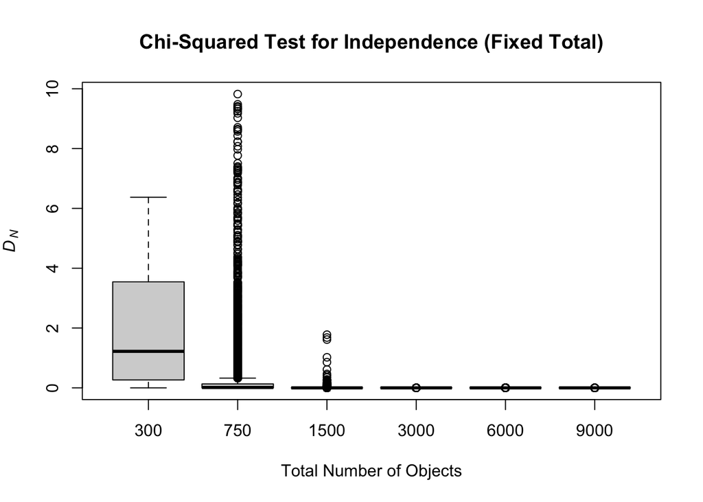

```r
boxplot(distMat6, names=size*3, ylab=expression(italic(D)[italic(N)]), xlab="Total Number of Objects",
        main="Chi-Squared Test for Independence (Fixed Total)") # create the boxplot
```

The regularity condition **R2** holds for the $\chi^2$-test.

The smallest sample size is $3\times100$ to ensure accuracy of the $\chi^{2}$ test with no cells having an expected count lower than 5.

scroll to top

### Cox Model

We model the observed time $Y_i=\min(T_i,\ C_i)$ and event indicator $\delta_i=\mathbf{1}_{T_i\leqslant C_i}$, where $C_i\overset{\text{i.i.d.}}{\sim}\operatorname{Exp}(0.2)$ are random and independent right-censoring times. The fitted model is a Cox proportional-hazards regression, and the $p$-value is from the Wald test based on the partial likelihood.

In this case, we assume
$$\begin{align}
T_i&\overset{\text{ind.}}{\sim}\operatorname{Exp}(\lambda_i) \\
&\ln{\lambda_i}=\beta_0+\beta_1 x_i\quad\text{for}\
i=1,\dotsb,N^*.
\end{align}$$

The sample size $N$ is the number of events. The degree of freedom is $q=1$.

The expected censoring fraction is $\mathbb{E}[\mathbb{P}(C<T\mid X)]=\mathbb{E}_{X\sim\mathcal{N}(0,1)}\left[\frac{0.2}{0.2+\exp\{\beta_0+\beta_1X\}} \right]\approx\operatorname{logit}^{-1}\left(\frac{\ln0.2-\beta_0}{\sqrt{1+\pi\beta_1^2/8}} \right)$, where $\operatorname{logit}^{-1}(t)=\frac{1}{1+e^{-t}}$.

#### **R1**

We set the model parameters to $\beta_0=0$ and $\beta_1=0$. The test is two-sided with null hypothesis $\mathcal{H}_0:\beta_1=0$.

```r
nSim <- 5000 # number of simulation runs for each setting
N <- c(25, 50, 100, 250, 500) # numbers of observations
```

```r
computeDist7 <- function(N, intercept=0, slope=0.5) {
  #' Input -
  #' N:              number of observations
  #' intercept:      true intercept
  #' slope:          true coefficient
  #'
  #' Dependency - survival (3.8-3)
  #' Output -
  #' a list of the p-value and $D_{N}=\sqrt{N}\cdot p\cdot(-\ln{p})$ in Eq. 7

  x <- stats::rnorm(N) # predictor variable
  lambda <- exp(intercept + slope * x) # rate parameter
  survTime <- stats::rexp(N, lambda) # survival time
  cenTime <- stats::rexp(N, 0.2) # right-censoring time
  dat <- list(time=pmin(survTime, cenTime),
              status=as.numeric(survTime <= cenTime),
              x=x)
  pVal <- summary(survival::coxph(survival::Surv(time, status) ~ x, dat))$coefficients["x", "Pr(>|z|)"]
  N <- sum(dat$status==1)
  list("p"=pVal,
       "D"=sqrt(N) * pVal * -log(pVal) ) # use number of events
}

set.seed(277)
pMat7 <- sapply(N, function(x) replicate(nSim, computeDist7(x, slope=0)$p)) # roughly 27 seconds of run time
```

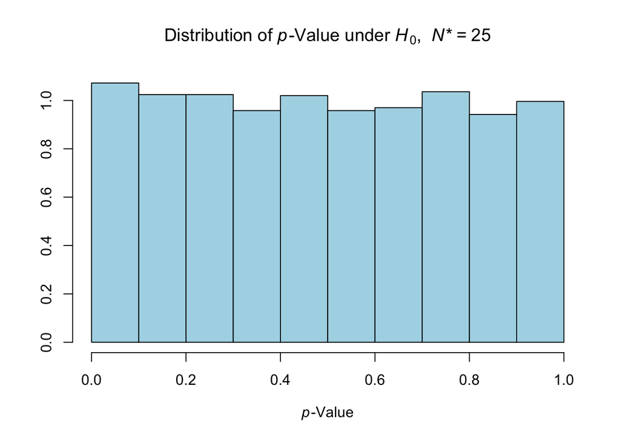

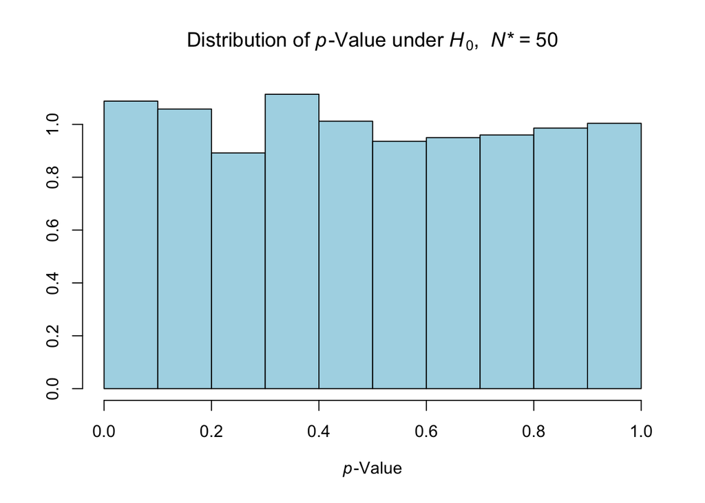

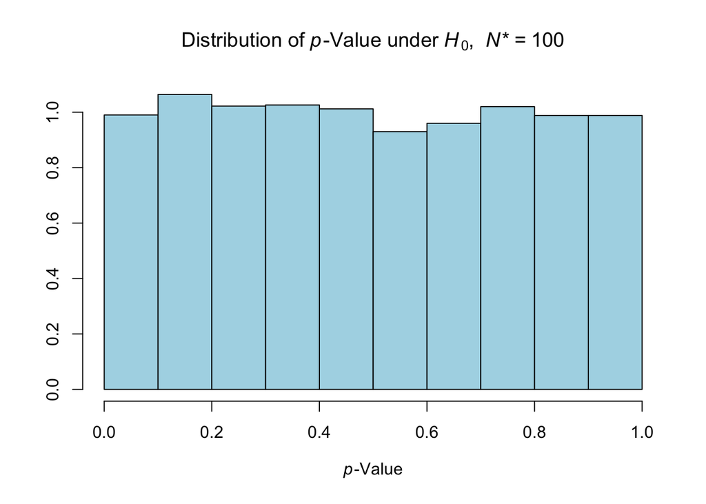

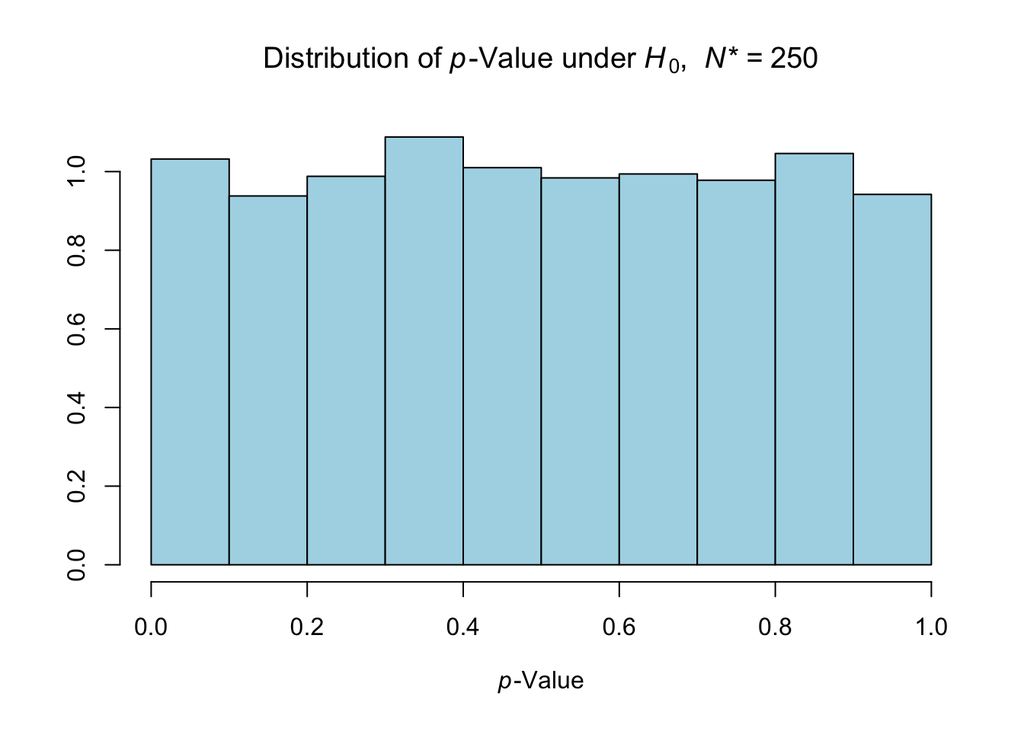

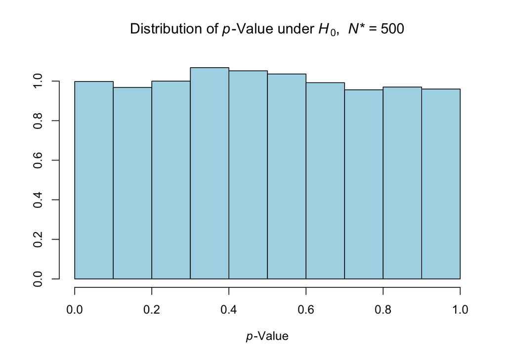

```r
for (i in 1:length(N)) {
  hist(pMat7[,i], prob=T, main=bquote("Distribution of " * italic("p") * "-Value under "
                                      * italic("H")[0] * ",  " * italic("N* = ") * .(N[i])),
       xlab=expression(italic(p) * "-Value"), ylab="", col="lightblue")
  cat("<br><br>")
} # create the histograms
```

Note that the smallest number of observations is $N^*=25$, because, with right censoring, the Cox model cannot estimate parameters when $N^*=10$.

The regularity condition **R1** appears to hold for the Cox proportional-hazards model.

scroll to top

#### **R2**

We set the model parameters to $\beta_0=0$ and $\beta_1=0.5$. The hazard ratio is $e^{\beta_1}\approx1.65$.

```r
set.seed(277)
distMat7 <- sapply(N, function(x) replicate(nSim, computeDist7(x)$D)) # roughly 27 seconds of run time
```

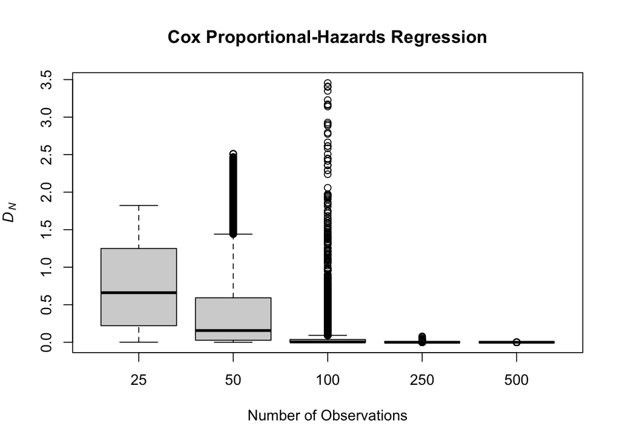

```r
boxplot(distMat7, names=N, ylab=expression(italic(D)[italic(N)]), xlab="Number of Observations",
        main="Cox Proportional-Hazards Regression") # create the boxplot
```

Note that the smallest number of observations is $N^*=25$, because, with right censoring, the Cox model cannot estimate parameters when $N^*=10$.

The regularity condition **R2** appears to hold for the Cox proportional-hazards model.

scroll to top

## 6. Unit-Information Prior

### One-Way ANOVA with Large Number of Groups

We obtained unexpected results from the BIC approximation-based methods in a one-way ANOVA, specifically when the number of groups is relatively large (e.g., up to five).

In the analysis below, the $p$-value is around 0.04, and the *anovaBF* function returns a value around 1. However, the BIC approximation yields an extreme value of 143 in favor of the null hypothesis.

```r
n <- 30        # number of observations per balanced group
a <- 5         # number of groups
m1 <- 0        # population mean of the first group (suppose the lowest)
delta <- 0.3   # evenly-spaced population mean difference, m2 - m1 = m3 - m2  = ···

set.seed(277)
data <- data.frame("resp" = rnorm(n * a, m1 + delta * (1:a - 1), 1),
                   "grp" = rep(paste0("grp", 1:a), n), stringsAsFactors=T)
summary(fit1 <- aov(resp ~ grp, data)) # full model fit
```

```
##              Df Sum Sq Mean Sq F value Pr(>F)
## grp           4  10.03  2.5078    2.53 0.0431 *
## Residuals   145 143.74  0.9913
## ---
## Signif. codes:  0 '***' 0.001 '**' 0.01 '*' 0.05 '.' 0.1 ' ' 1
```

```r
FVal <- summary(fit1)[[1]]["grp", "F value"] # F-ratio

1 / BayesFactor::anovaBF(resp ~ grp, data, progress=F) # JZS-BF₀₁
```

```
## Bayes factor analysis
## --------------
## [1] Intercept only : 1.13705 ±0%
##
## Against denominator:
##   resp ~ grp
## ---
## Bayes factor type: BFlinearModel, JZS
```

```r
# BIC approximation
fit0 <- aov(resp ~ 1, data)    # null model fit
exp((BIC(fit1) - BIC(fit0)) / 2) # BIC-BF₀₁
```

```
## [1] 142.8294
```

```r
# Jeffreys approximate Bayes factor (Λ → (a-1)⋅F)
(n*a)^((a-1)/2) * exp(-0.5 * (a-1) * FVal) # original JAB₀₁
```

```
## [1] 142.8158
```

```r
sqrt(n*a) * exp(-0.5 * (a-1) * FVal * ((n*a)^(1/(a-1))-1) / (n*a)^(1/(a-1))) # extended JAB₀₁
```

```
## [1] 0.330016
```

scroll to top

### Chi-Squared Tests for Independence

We have encountered a similar issue with BIC approximation-based methods in chi-squared tests for independence.

Consider a scenario where the total number of observations is 200, and the contingency table is $3\times4$. A $p$-value of 0.01 corresponds to an original $\mathit{JAB}_{01}$ value of 1865 in favor of the null hypothesis, while a $p$-value of 0.0001 corresponds to an original $\mathit{JAB}_{01}$ value of 7.66, also in favor of the null. These results seem paradoxical.

```r
pVal <- .0001; N <- 200; R <- 3; C <- 4; df <- (R-1) * (C-1)

N^(df/2) * exp(-0.5 * qchisq(1-pVal, df) * (N-1) / N) # original JAB₀₁
```

```
## [1] 7.663144
```

```r
sqrt(N) * exp(-0.5 * qchisq(1-pVal, df) * (N^(1/df)-1) / N^(1/df)) # extended JAB₀₁
```

```
## [1] 0.004008032
```

## 7. Nonparametric

### Wilcoxon Signed-Rank Test

The Wilcoxon signed-rank test is a nonparametric alternative to the one-sample or paired $t$-test. It tests hypotheses about the median of differences.

The sample size $N$ is the number of paired observations. The degree of freedom is $q=1$.

#### **R1**

```r
nSim <- 5000 # number of simulation runs for each setting
n <- c(10, 25, 50, 100, 250, 500) # numbers of paired observations
```

```r
computeDist8 <- function(n, mu=c(0, 0.5), S=matrix(c(1, 0.9, 0.9, 1), 2), nu=3) {
  #' Input -
  #' n:           number of paired observations
  #' mu:          population means
  #' S:           scale matrix for paired observations
  #' nu:          degrees of freedom of the multivariate t
  #'
  #' Output -
  #' a list of the p-value and $D_{N}=\sqrt{N}\cdot p\cdot(-\ln{p})$ in Eq. 7

  Y <- LaplacesDemon::rmvt(n, mu, S, nu)
  pVal <- stats::wilcox.test(Y[,1], Y[,2], paired=T)$p.value

  list("p"=pVal,
       "D"=sqrt(n) * pVal * -log(pVal) )
}

set.seed(277)
pMat8 <- sapply(n, function(x) replicate(nSim, computeDist8(x, c(0, 0))$p)) # roughly 7.8 seconds of run time
```

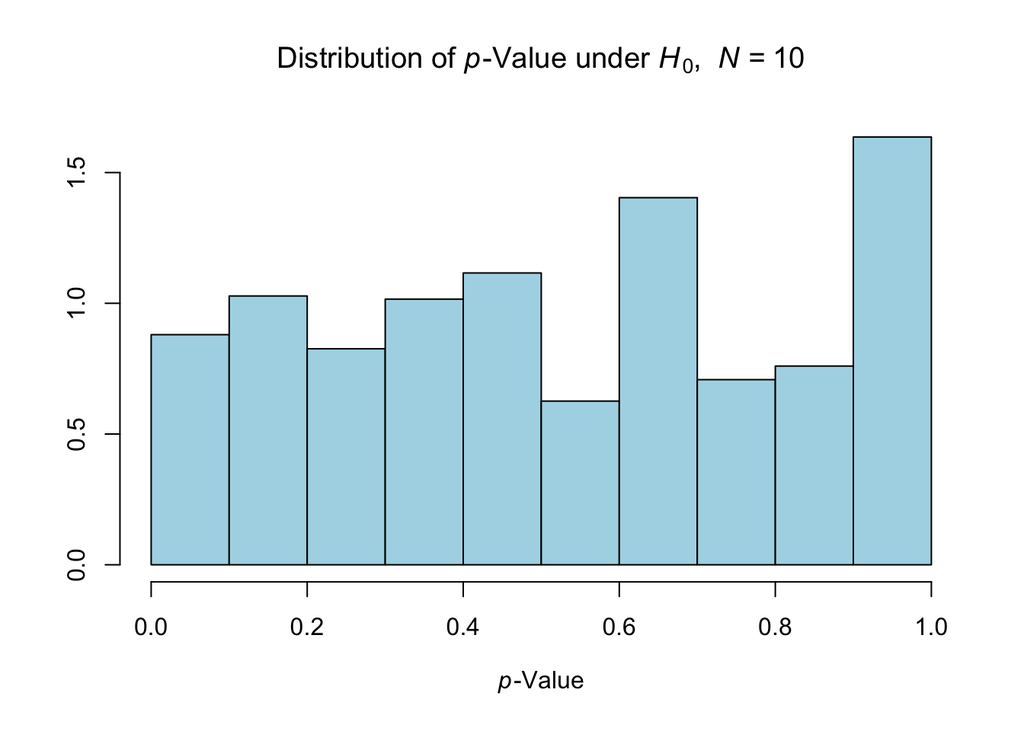

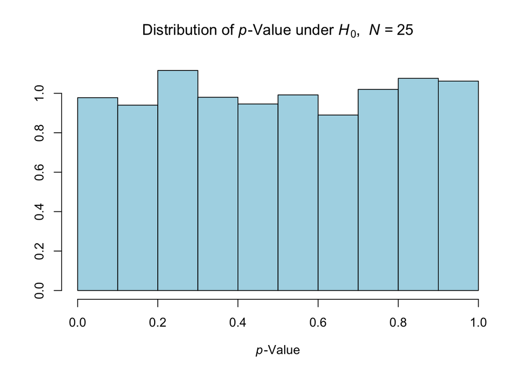

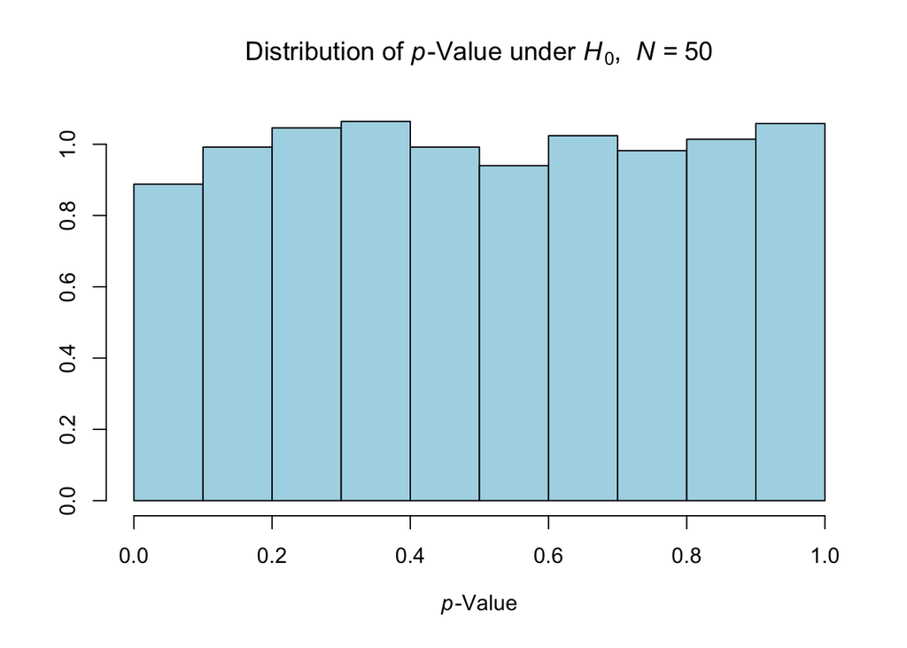

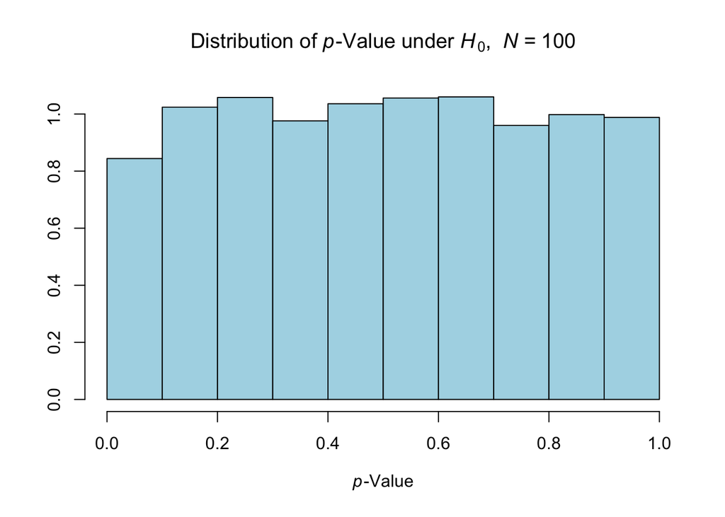

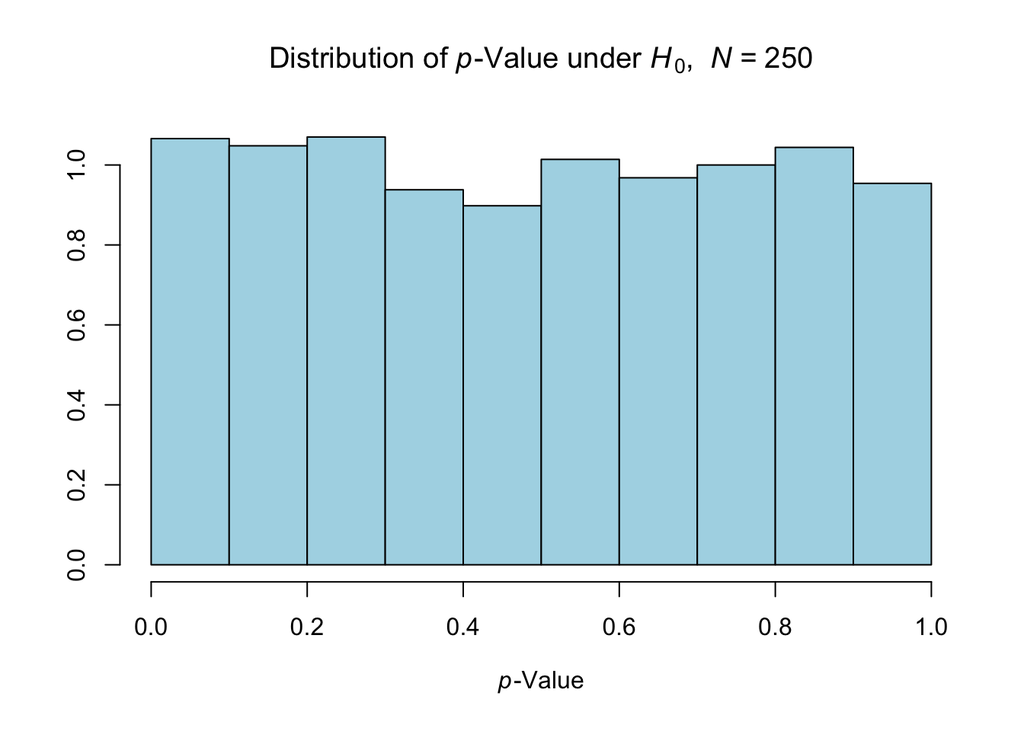

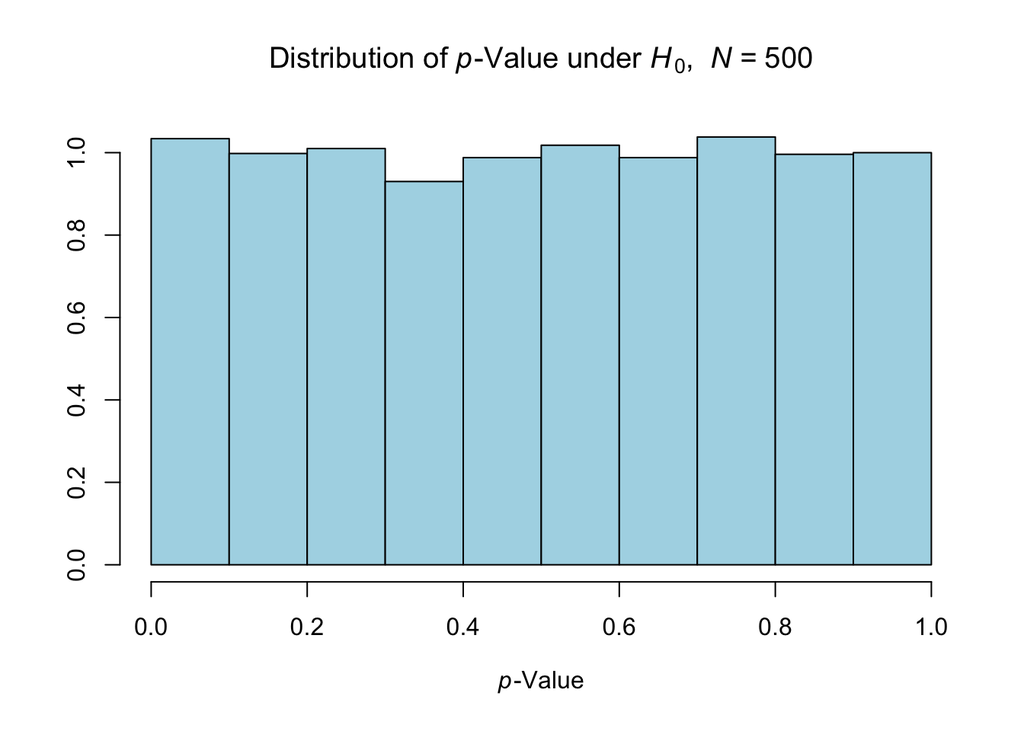

```r
for (i in 1:length(n)) {
  hist(pMat8[,i], prob=T, main=bquote("Distribution of " * italic("p") * "-Value under "
                                      * italic("H")[0] * ",  " * italic("N = ") * .(n[i])),
       xlab=expression(italic(p) * "-Value"), ylab="", col="lightblue")
  cat("<br><br>")
} # create the histograms
```

scroll to top

#### **R2**

```r
set.seed(277)
distMat8 <- sapply(n, function(x) replicate(nSim, computeDist8(x)$D)) # roughly 7.6 seconds of run time
```

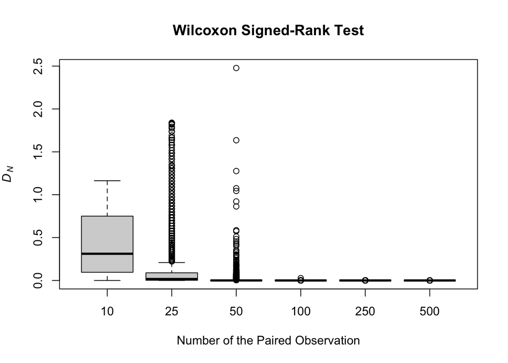

```r
boxplot(distMat8, names=n, ylab=expression(italic(D)[italic(N)]), xlab="Number of the Paired Observation",
        main="Wilcoxon Signed-Rank Test") # create the boxplot
```

scroll to top

### Mann–Whitney $U$-Test

The Mann–Whitney $U$-test (also called the Wilcoxon rank-sum test) is a nonparametric alternative to the two-sample $t$-test. It tests the null hypothesis that two distributions are identical.

The sample size $N=n_1+n_2$ is the total number of observations. The degree of freedom is $q=1$.

#### **R1**

```r
nSim <- 5000 # number of simulation runs for each setting
n <- c(10, 25, 50, 100, 250, 500) # numbers of observations per balanced group
```

```r
computeDist9 <- function(n, mu1=0, mu2=0.5, S1=1, S2=1, nu=3) {
  #' Input -
  #' n:           numbers of observations per balanced group
  #' mu1:         population mean of the first group
  #' mu2:         population mean of the second group
  #' S1, S2:      scale parameters for the two population distributions
  #' nu:          degrees of freedom of the t-distributions
  #'
  #' Dependency - LaplacesDemon (v16.1.6)
  #' Output -
  #' a list of the p-value and $D_{N}=\sqrt{N}\cdot p\cdot(-\ln{p})$ in Eq. 7

  y1 <- LaplacesDemon::rmvt(n, mu1, S1, nu)
  y2 <- LaplacesDemon::rmvt(n, mu2, S2, nu)
  pVal <- stats::wilcox.test(y1, y2)$p.value
  list("p"=pVal,
       "D"=sqrt(n * 2) * pVal * -log(pVal) ) # use total number of observations
}

set.seed(277)
pMat9 <- sapply(n, function(x) replicate(nSim, computeDist9(x, mu2=0)$p)) # roughly 12 seconds of run time
```

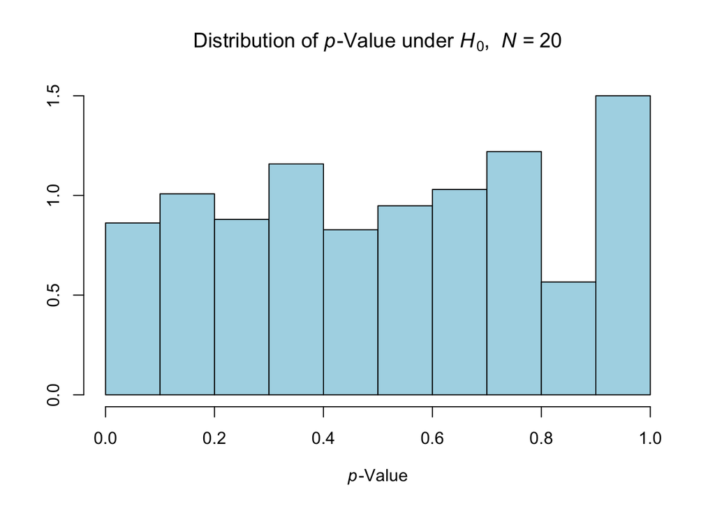

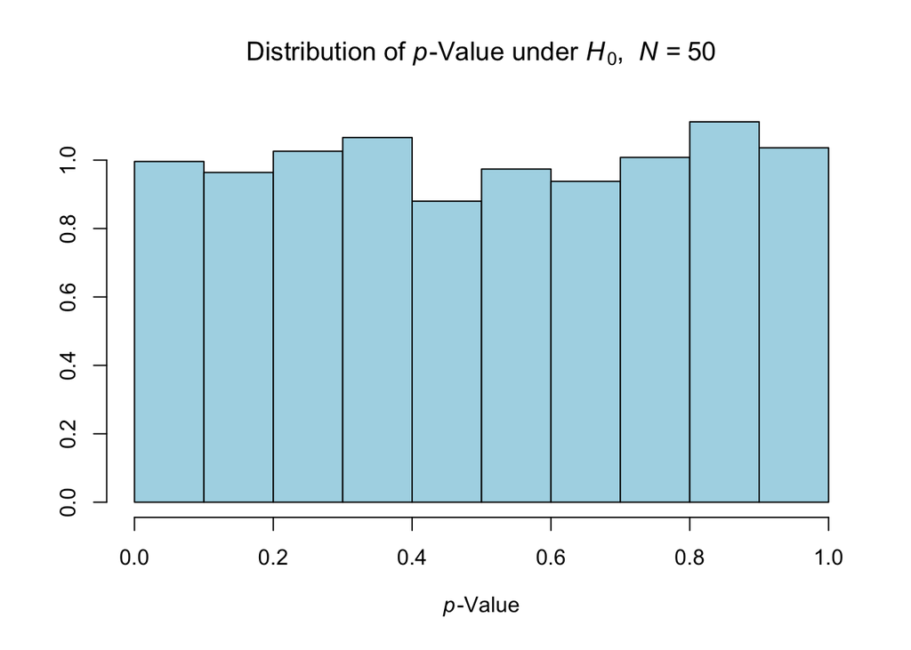

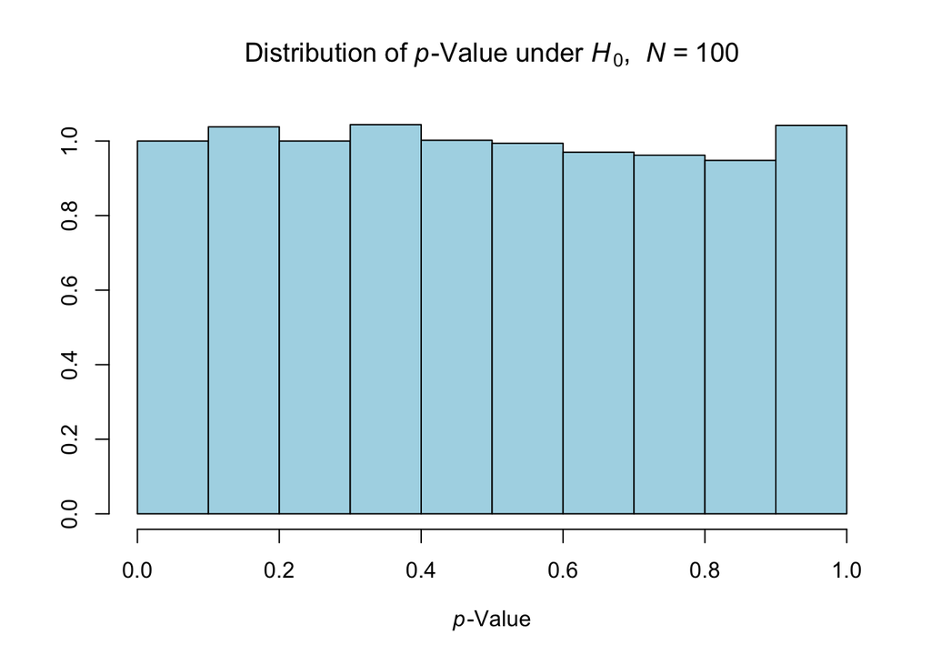

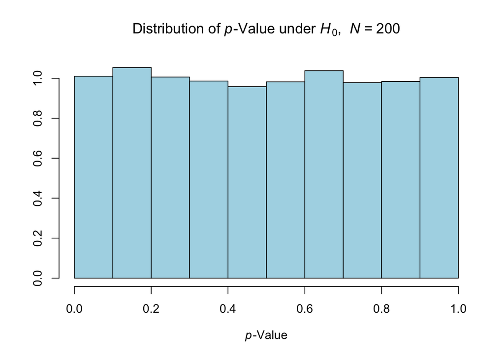

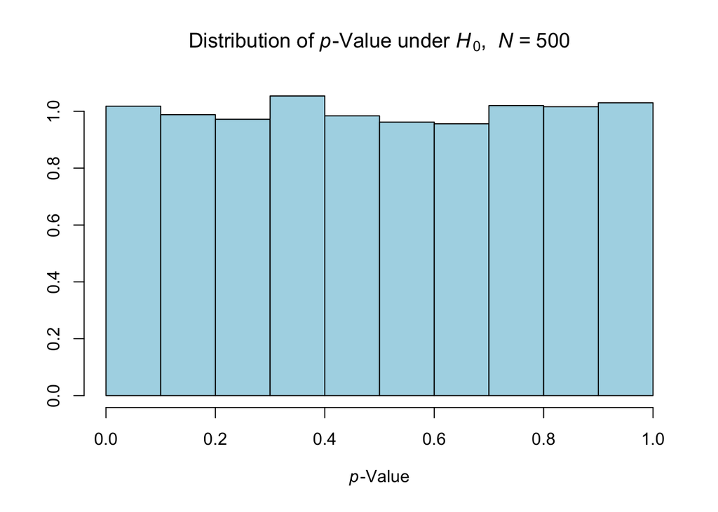

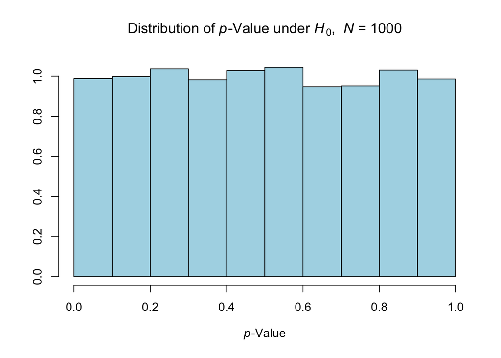

```r
for (i in 1:length(n)) {
  hist(pMat9[,i], prob=T, main=bquote("Distribution of " * italic("p") * "-Value under "
                                      * italic("H")[0] * ",  " * italic("N = ") * .(2*n[i])),
       xlab=expression(italic(p) * "-Value"), ylab="", col="lightblue")
  cat("<br><br>")
} # create the histograms
```

scroll to top

#### **R2**

```r
set.seed(277)
distMat9 <- sapply(n, function(x) replicate(nSim, computeDist9(x)$D)) # roughly 12 seconds of run time
```

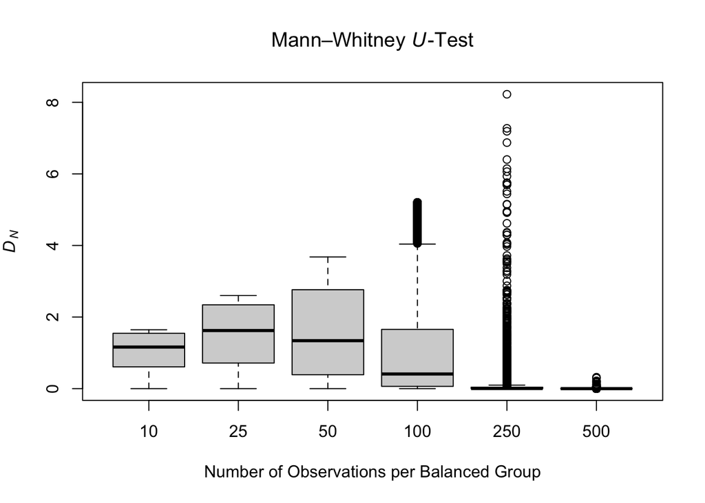

```r
boxplot(distMat9, names=n, ylab=expression(italic(D)[italic(N)]),
        xlab="Number of Observations per Balanced Group",
        main=expression("Mann–Whitney " * italic(U) * "-Test")) # create the boxplot
```

scroll to top

### Kruskal–Wallis $H$-Test

The Kruskal–Wallis $H$-test is a nonparametric alternative to the one-way ANOVA. It tests the null hypothesis that all groups have identical distributions.

The sample size $N=nI$ is the total number of observations. The degrees of freedom are $q=I-1$.

#### **R1**

```r
nSim <- 5000 # number of simulation runs for each setting
n <- c(10, 25, 50, 100, 250, 500) # numbers of observations per balanced group
```

```r
computeDist10 <- function(n, a=5, delta=0.5, mu=0, sigma=1, alpha=0.5, nu=4) {
  #' Input -
  #' n:           number of observations per balanced group
  #' a:           number of groups
  #' delta:       population mean range
  #' mu:          population mean of the first group (suppose the lowest)
  #' sigma:       scale parameter for each population
  #' alpha:       slant parameter for the skew-t distribution
  #' nu:          degrees of freedom of the skew-t distribution
  #'
  #' Dependency - sn (v2.1.1)
  #' Output -
  #' a list of the p-value and $D_{N}=\sqrt{N}\cdot p\cdot(-\ln{p})$ in Eq. 7

  mu.vec <- seq(mu, mu+delta, length.out=a) # population means
  df <- data.frame("resp"=sn::rst(n * a, mu.vec, sigma, alpha, nu),
                   "grp"=rep(paste0("grp", 1:a), n),
                   stringsAsFactors=T)
  pVal <- stats::kruskal.test(resp ~ grp, df)$p.value
  list("p"=pVal,
       "D"=sqrt(n * a) * pVal * -log(pVal) ) # use total number of observations
}

set.seed(277)
pMat10 <- sapply(n, function(x) replicate(nSim, computeDist10(x, delta=0)$p)) # roughly 55 seconds of run time
```

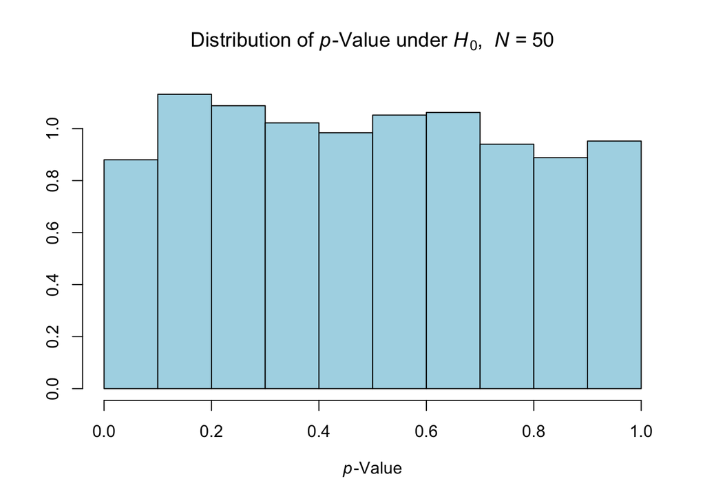

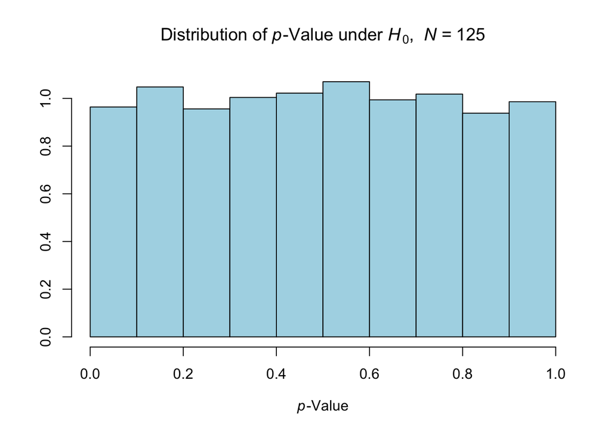

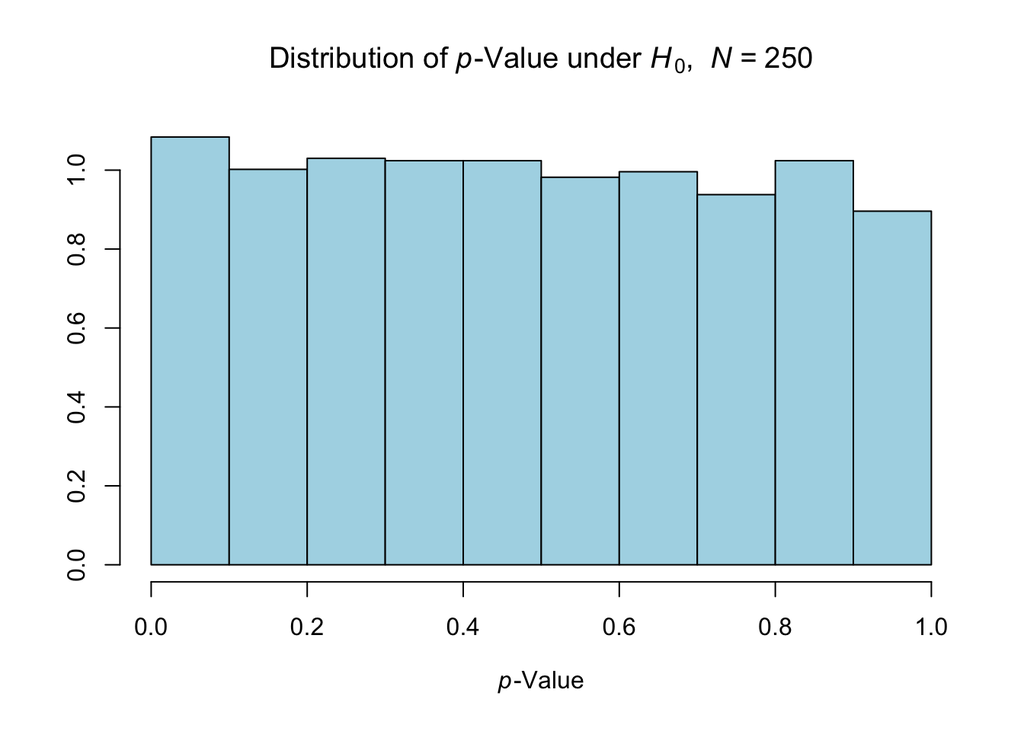

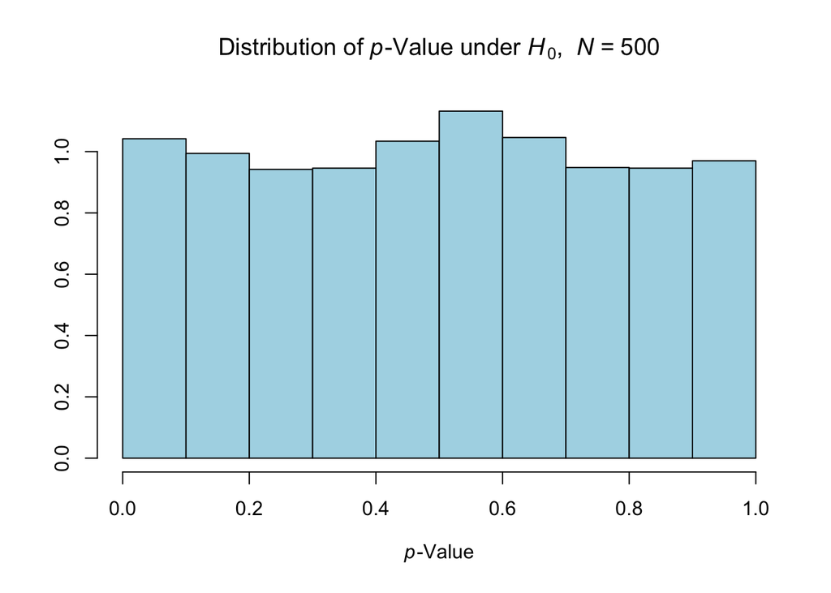

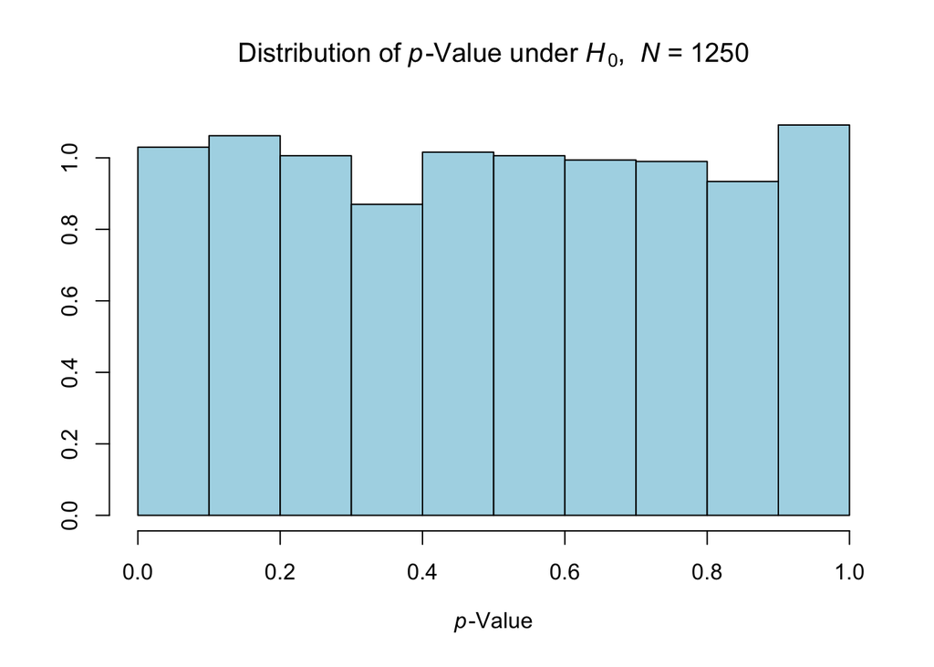

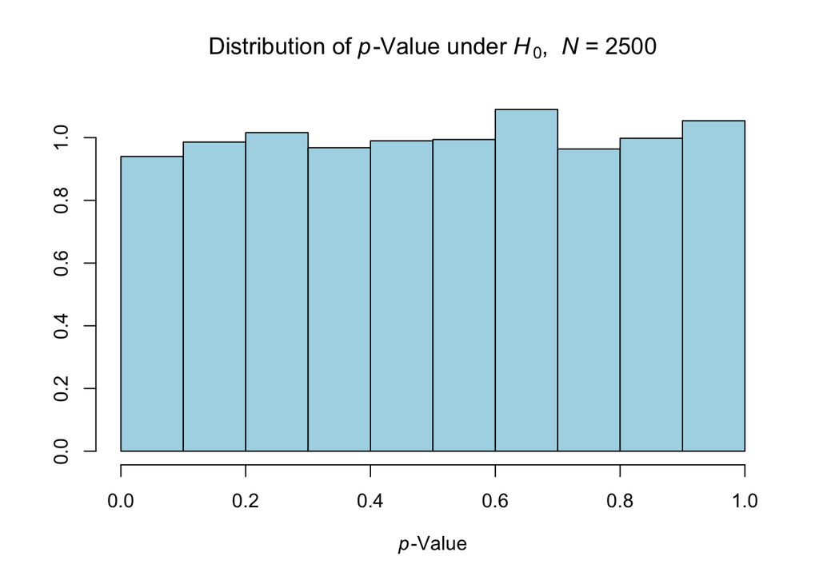

```r
for (i in 1:length(n)) {
  hist(pMat10[,i], prob=T, main=bquote("Distribution of " * italic("p") * "-Value under "
                                       * italic("H")[0] * ",  " * italic("N = ") * .(5*n[i])),
       xlab=expression(italic(p) * "-Value"), ylab="", col="lightblue")
  cat("<br><br>")
} # create the histograms
```

scroll to top

#### **R2**

```r
set.seed(277)
distMat10 <- sapply(n, function(x) replicate(nSim, computeDist10(x)$D)) # roughly 56 seconds of run time
```

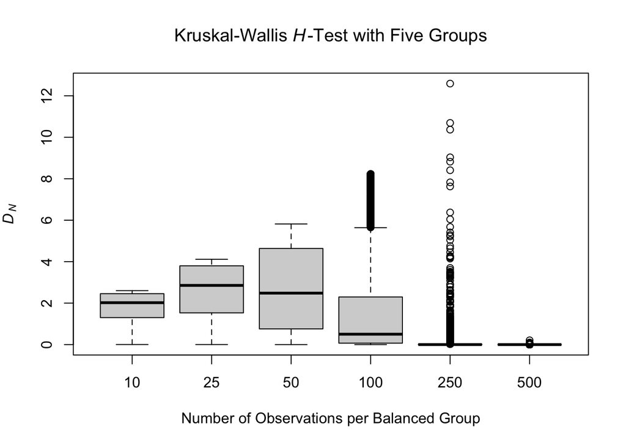

```r
boxplot(distMat10, names=n, ylab=expression(italic(D)[italic(N)]),
        xlab="Number of Observations per Balanced Group",
        main=expression("Kruskal-Wallis " * italic(H) * "-Test with Five Groups")) # create the boxplot
```

scroll to top

## 8. *clogit*

In a 1:1 matched case–control study, we assume that the conditional likelihood is as follows

$$\begin{align}
&\mathbb{P}\left(Y_{ij}=1\mid\mathbf{x}_{i1},\ \mathbf{x}_{i2},\
Y_{i1}+Y_{i2}=1\right)=\frac{\exp\left\{\boldsymbol{\beta}^\top\mathbf{x}_{ij}\right\}}{\exp\left\{\boldsymbol{\beta}^\top\mathbf{x}_{i1}\right\}+\exp\left\{\boldsymbol{\beta}^\top\mathbf{x}_{i2}\right\}}
\\
&\mathbf{x}_{ij}=(x_{1,ij},\ x_{2,ij})^\top\quad\text{for the
observation}\ j\in\{1,2\}\ \text{of the stratum}\ i=1,\dotsb,N^*.
\end{align}$$

The sample size $N$ is the number of matched pairs in which the case and control have different exposure values. The degree of freedom is $q=1$.

### **R1**

We set the model parameters to $\beta_1=0$ and $\beta_2=0.25$. The test is two-sided with null hypothesis $\mathcal{H}_0:\beta_1=0$.

```r
nSim <- 5000 # number of simulation runs for each setting
n <- c(100, 220, 340, 460, 580, 700) # number of pairs
```

```r
computeDist11 <- function(n, beta1=0.25, beta2=0.25) {
  #' Input -
  #' n:              number of pairs (>= number of matched pairs)
  #' beta1:          true coefficient for the first predictor
  #' beta2:          true coefficient for the second predictor
  #'
  #' Dependency - survival (v3.8-3)
  #' Output -
  #' a list of the p-value and $D_{N}=\sqrt{N}\cdot p\cdot(-\ln{p})$ in Eq. 7

  # two observations per stratum
  x1 <- stats::rnorm(2 * n)
  x2 <- stats::rbinom(2 * n, 1, .5)
  logitP <- beta1 * x1 + beta2 * x2
  strata <- rep(1:n, each=2)
  y <- unlist(lapply(split(logitP, strata), function(x) stats::rbinom(2, 1, exp(x) / sum(exp(x)))))

  # one case and one control per stratum
  valid <- rep(tapply(y, strata, sum)==1, each=2)
  df <- data.frame(y, x1, x2, "s"=strata)[valid,]

  fit <- survival::clogit(y ~ x1 + x2 + survival::strata(s), df)
  pVal <- summary(fit)$coefficients[,"Pr(>|z|)"][1]
  N <- nrow(df) / 2
  list("p"=pVal,
       "D"=sqrt(N) * pVal * -log(pVal) ) # use number of matched pairs
}

set.seed(277)
pMat11 <- sapply(n, function(x) replicate(nSim, computeDist11(x, beta1=0)$p)) # roughly 112 seconds of run time
```

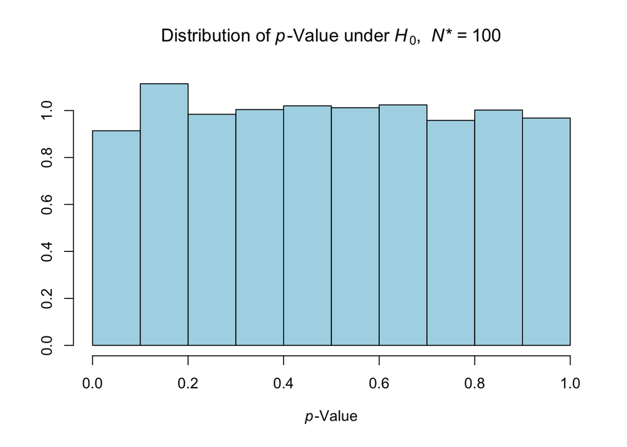

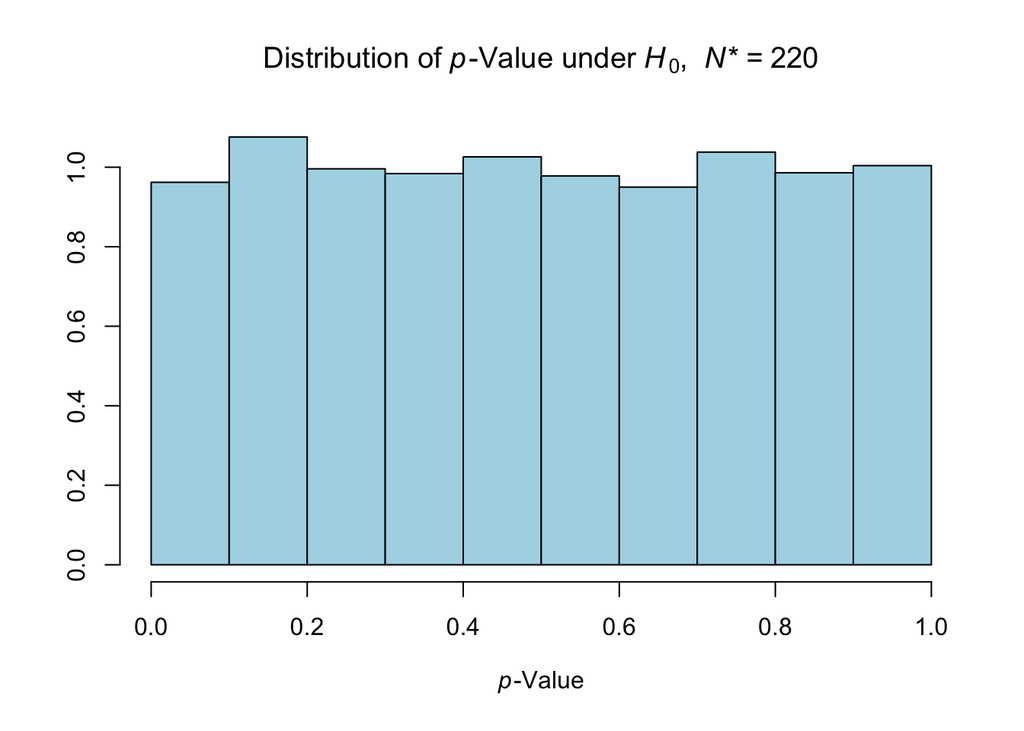

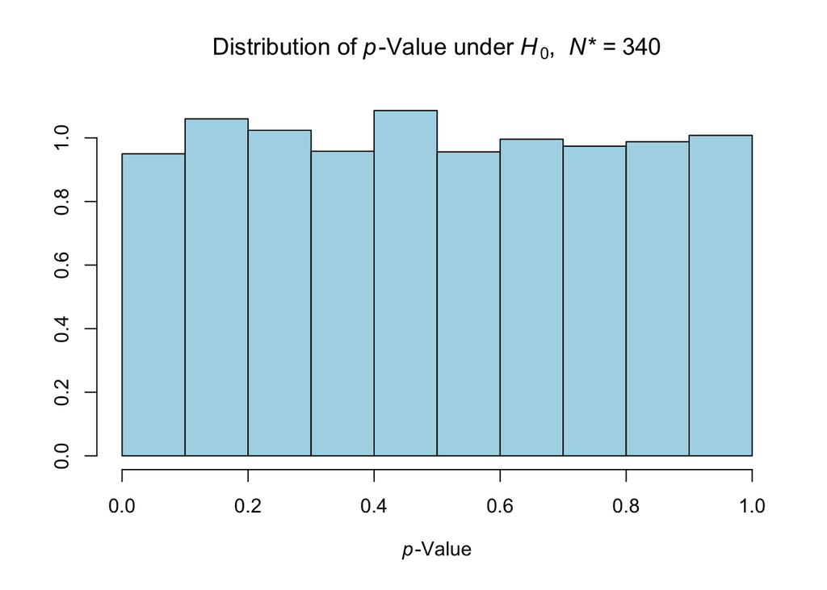

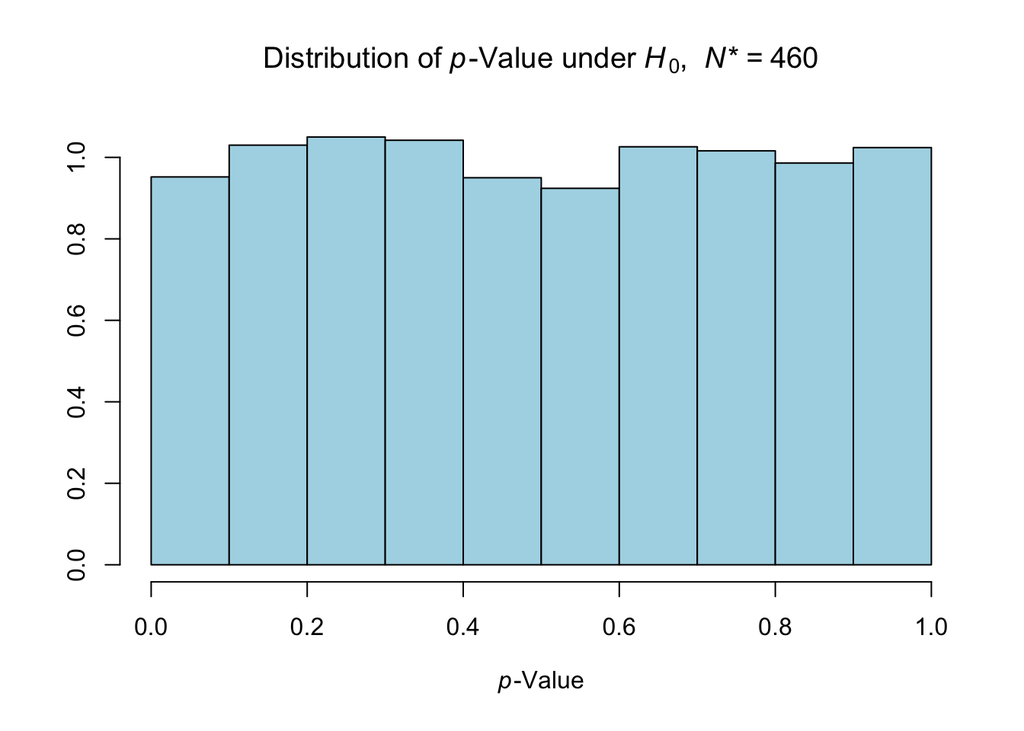

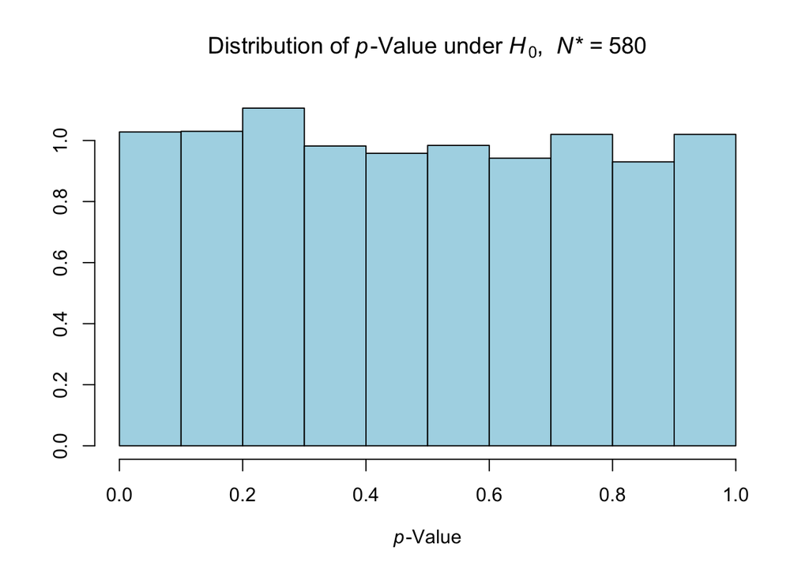

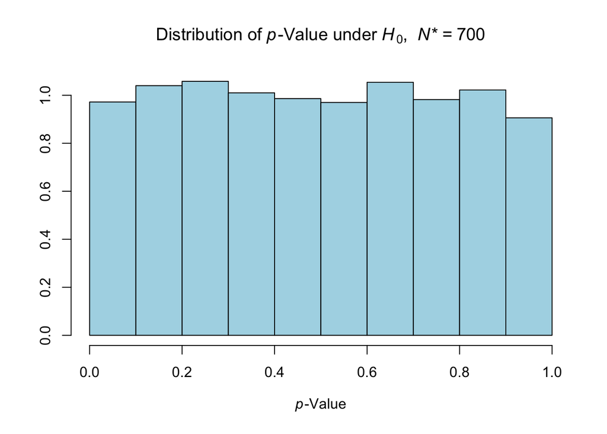

```r
for (i in 1:length(n)) {
  hist(pMat11[,i], prob=T, main=bquote("Distribution of " * italic("p") * "-Value under "
                                       * italic("H")[0] * ",  " * italic("N* = ") * .(n[i])),
       xlab=expression(italic(p) * "-Value"), ylab="", col="lightblue")
  cat("<br><br>")
} # create the histograms
```

The regularity condition **R1** appears to hold for conditional logistic regression.

scroll to top

### **R2**

We set the model parameters to $\beta_1=0.25$ and $\beta_2=0.25$. The odds ratio is $e^{\beta_1}\approx1.28$.

```r
set.seed(277)
distMat11 <- sapply(n, function(x) replicate(nSim, computeDist11(x)$D)) # roughly 104 seconds of run time
```

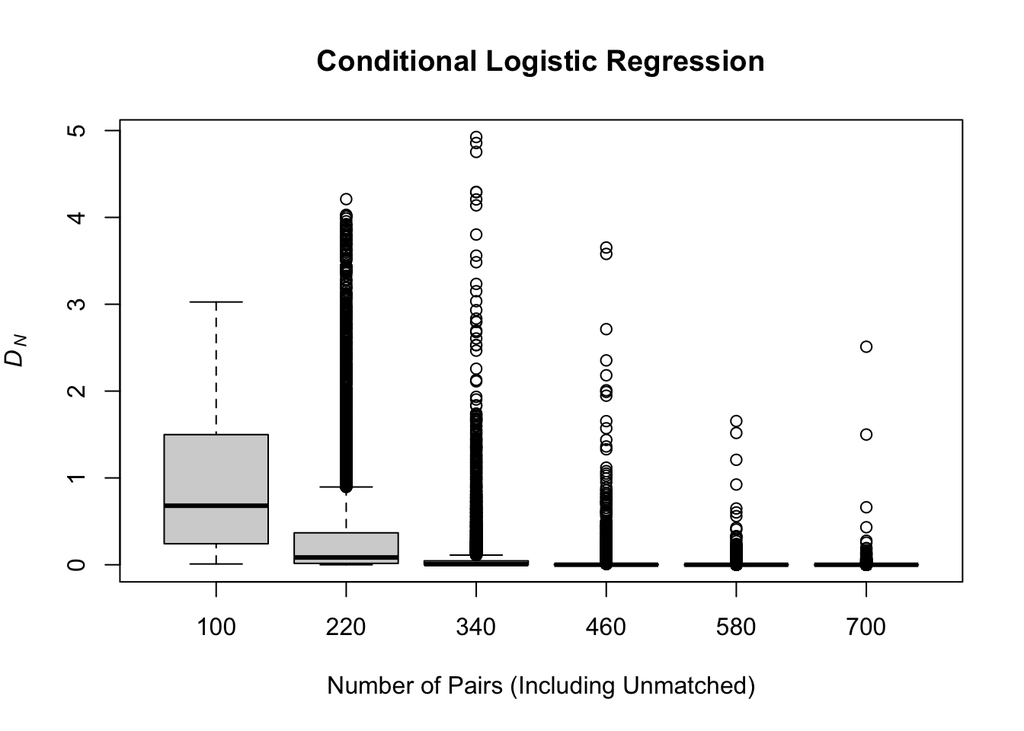

```r
boxplot(distMat11, names=n, ylab=expression(italic(D)[italic(N)]), xlab="Number of Pairs (Including Unmatched)",
        main="Conditional Logistic Regression") # create the boxplot
```

The regularity condition **R2** appears to hold for conditional logistic regression.

scroll to top